A Visual Exploration and Analysis  
of Diabetes Dataset

## Table of Content

1. **Overview**
2. **Data Description**
3. **Data Cleaning**
4. **Data Exploration**
5. **Data Visualization & Analysis**
6. **Conclusion**

1. Overview

The dataset has a total of **768 rows** each referring to patients characterized by **9 numeric variables** . The data refers to females of ages from 21 to 81 years. The nine attributes can be further classified as

A) Six attributes describe the result of physical / verbal examination  
1) Number of times pregnant  
2) Diastolic blood pressure (mm Hg)  
3) Triceps skin fold thickness (mm)  
4) Body mass index (weight in kg/(height in m)2)  
5) Diabetes pedigree function - a function which scores probability of getting diabetes based on family history  
6) Age (years)

B) Two attributes are result of chemical examination  
7) Plasma glucose concentration over 2 hours in an oral glucose tolerance test  
8) 2-Hour serum insulin (mu U/ml)

C) Resultant Target Variable  
9) Class variable -0 (No) if non-diabetic, 1 (Yes) if diabetic

Objective:

of this data analysis is to find the significant factors in the first 8 variables which influence the 9th variable that is if (Resultant)(diabetes=yes (1) diabetes = no (0)) through data analysis and visualization techniques using Python

Diabetic Dataset and Jupyter program is hosted in **Github** to enable concurrent and collabrative working within the team

[figure not shown]

2. Data Description

```python
#importing libraries for analyzing our data
import numpy as np
import pandas as pd
import matplotlib.pyplot as plt
import seaborn as sns
import plotly.graph_objects as go
from IPython.display import Image
import warnings
warnings.simplefilter(action='ignore', category=FutureWarning)
```

## Loading data and viewing first five rows

```python
# dataset is hosted at Github following path - https://raw.githubusercontent.com/meetAmarAtGithub/PES_MTech_Assignments/master/NPV_Statitical%20Anlysis%20of%20Diabetes%20Dataset/diabetes.csv
df1 = pd.read_csv('https://raw.githubusercontent.com/meetAmarAtGithub/PES_MTech_Assignments/master/NPV_Statitical%20Anlysis%20of%20Diabetes%20Dataset/diabetes.csv')
df1.head()
```

|  | Number of times pregnant | Plasma glucose concentration a 2 hours in an oral glucose tolerance test | Diastolic blood pressure (mm Hg) | Triceps skin fold thickness (mm) | 2-Hour serum insulin (mu U/ml) | Body mass index (weight in kg/(height in m)^2) | Diabetes pedigree function | Age (years) | Class variable |
| --- | --- | --- | --- | --- | --- | --- | --- | --- | --- |
| 0 | 6 | 148 | 72 | 35 | 0 | 33.6 | 0.627 | 50 | 1 |
| 1 | 1 | 85 | 66 | 29 | 0 | 26.6 | 0.351 | 31 | 0 |
| 2 | 8 | 183 | 64 | 0 | 0 | 23.3 | 0.672 | 32 | 1 |
| 3 | 1 | 89 | 66 | 23 | 94 | 28.1 | 0.167 | 21 | 0 |
| 4 | 0 | 137 | 40 | 35 | 168 | 43.1 | 2.288 | 33 | 1 |

```python
df1.info()
```

```
<class 'pandas.core.frame.DataFrame'>
RangeIndex: 768 entries, 0 to 767
Data columns (total 9 columns):
 #   Column                                                                    Non-Null Count  Dtype
---  ------                                                                    --------------  -----
 0   Number of times pregnant                                                  768 non-null    int64
 1   Plasma glucose concentration a 2 hours in an oral glucose tolerance test  768 non-null    int64
 2   Diastolic blood pressure (mm Hg)                                          768 non-null    int64
 3   Triceps skin fold thickness (mm)                                          768 non-null    int64
 4   2-Hour serum insulin (mu U/ml)                                            768 non-null    int64
 5   Body mass index (weight in kg/(height in m)^2)                            768 non-null    float64
 6   Diabetes pedigree function                                                768 non-null    float64
 7   Age (years)                                                               768 non-null    int64
 8   Class variable                                                            768 non-null    int64
dtypes: float64(2), int64(7)
memory usage: 54.1 KB
```

### Check for NAN in DataFrame

```python
df1.isna().sum()
```

```
Number of times pregnant                                                    0
Plasma glucose concentration a 2 hours in an oral glucose tolerance test    0
Diastolic blood pressure (mm Hg)                                            0
Triceps skin fold thickness (mm)                                            0
2-Hour serum insulin (mu U/ml)                                              0
Body mass index (weight in kg/(height in m)^2)                              0
Diabetes pedigree function                                                  0
Age (years)                                                                 0
Class variable                                                              0
dtype: int64
```

**Observation :**  
There is no NaN in dataframe.

### Check for duplicate rows in Dataframe

```python
# Select duplicate rows except first occurrence based on all columns
duplicateRowsDF = df1[df1.duplicated()]
print("Duplicate Rows except first occurrence based on all columns are :")
print(duplicateRowsDF)
```

```
Duplicate Rows except first occurrence based on all columns are :
Empty DataFrame
Columns: [Number of times pregnant, Plasma glucose concentration a 2 hours in an oral glucose tolerance test, Diastolic blood pressure (mm Hg), Triceps skin fold thickness (mm), 2-Hour serum insulin (mu U/ml), Body mass index (weight in kg/(height in m)^2), Diabetes pedigree function, Age (years), C…
Index: []
```

**Observation :**  
There are no duplicate rows

3. DataCleaning

### Generate descriptive statistics

```python
round(df1.describe(),2)
```

|  | Number of times pregnant | Plasma glucose concentration a 2 hours in an oral glucose tolerance test | Diastolic blood pressure (mm Hg) | Triceps skin fold thickness (mm) | 2-Hour serum insulin (mu U/ml) | Body mass index (weight in kg/(height in m)^2) | Diabetes pedigree function | Age (years) | Class variable |
| --- | --- | --- | --- | --- | --- | --- | --- | --- | --- |
| count | 768.00 | 768.00 | 768.00 | 768.00 | 768.00 | 768.00 | 768.00 | 768.00 | 768.00 |
| mean | 3.85 | 120.89 | 69.11 | 20.54 | 79.80 | 31.99 | 0.47 | 33.24 | 0.35 |
| std | 3.37 | 31.97 | 19.36 | 15.95 | 115.24 | 7.88 | 0.33 | 11.76 | 0.48 |
| min | 0.00 | 0.00 | 0.00 | 0.00 | 0.00 | 0.00 | 0.08 | 21.00 | 0.00 |
| 25% | 1.00 | 99.00 | 62.00 | 0.00 | 0.00 | 27.30 | 0.24 | 24.00 | 0.00 |
| 50% | 3.00 | 117.00 | 72.00 | 23.00 | 30.50 | 32.00 | 0.37 | 29.00 | 0.00 |
| 75% | 6.00 | 140.25 | 80.00 | 32.00 | 127.25 | 36.60 | 0.63 | 41.00 | 1.00 |
| max | 17.00 | 199.00 | 122.00 | 99.00 | 846.00 | 67.10 | 2.42 | 81.00 | 1.00 |

#### Check for abnormality in minimum value being zero's

```python
round(df1.describe().min(),0)
```

```
Number of times pregnant                                                     0.0
Plasma glucose concentration a 2 hours in an oral glucose tolerance test     0.0
Diastolic blood pressure (mm Hg)                                             0.0
Triceps skin fold thickness (mm)                                             0.0
2-Hour serum insulin (mu U/ml)                                               0.0
Body mass index (weight in kg/(height in m)^2)                               0.0
Diabetes pedigree function                                                   0.0
Age (years)                                                                 12.0
Class variable                                                               0.0
dtype: float64
```

**Observation :**  
Minimum values for many variables are 0.  
As biological parameters like Glucose, BP, Skin thickness,Insulin & BMI cannot have zero values, looks like null values have been coded as zeros  
As a next step, find out how many Zero values are included in each variable

#### Checking for count of zeroes for each column

```python
print(df1.isin([0]).sum())
```

```
Number of times pregnant                                                    111
Plasma glucose concentration a 2 hours in an oral glucose tolerance test      5
Diastolic blood pressure (mm Hg)                                             35
Triceps skin fold thickness (mm)                                            227
2-Hour serum insulin (mu U/ml)                                              374
Body mass index (weight in kg/(height in m)^2)                               11
Diabetes pedigree function                                                    0
Age (years)                                                                   0
Class variable                                                              500
dtype: int64
```

[figure not shown]

**Observation :**  
Preganancy and Result can have zero values hence ignored  
As Zero count of Glucose (5) , Blood Pressure (35) and BMI (11) are low it is recommended to remove the Zeros uniformly for these 3 variables  
As Zero Counts of Insulin (374) and Skin Thicknesss 227, in a 768 data set need to be investigated to prevent ~ 50% sample size reduction  
As a next step, suitablity of Mean or Median replacement will be investigated

#### Finding the optimial values to replace in skin thickness and insulin levels to replace zero values

```python
# create a temporary dataframe removing zero values to avoid skew in mean and median
df2 = df1[df1['2-Hour serum insulin (mu U/ml)'] > 0]
print(df2.isin([0]).sum())
```

```
Number of times pregnant                                                     57
Plasma glucose concentration a 2 hours in an oral glucose tolerance test      1
Diastolic blood pressure (mm Hg)                                              0
Triceps skin fold thickness (mm)                                              0
2-Hour serum insulin (mu U/ml)                                                0
Body mass index (weight in kg/(height in m)^2)                                1
Diabetes pedigree function                                                    0
Age (years)                                                                   0
Class variable                                                              264
dtype: int64
```

```python
# find the grouped mean and median of insulin level
grouped_df =df2.groupby('Class variable')
smean = round(grouped_df['2-Hour serum insulin (mu U/ml)'].mean(),2)
smedian =round(grouped_df['2-Hour serum insulin (mu U/ml)'].median(),2)
smean
smedian
```

```
Class variable
0    102.5
1    169.5
Name: 2-Hour serum insulin (mu U/ml), dtype: float64
```

```python
df2.head()
```

|  | Number of times pregnant | Plasma glucose concentration a 2 hours in an oral glucose tolerance test | Diastolic blood pressure (mm Hg) | Triceps skin fold thickness (mm) | 2-Hour serum insulin (mu U/ml) | Body mass index (weight in kg/(height in m)^2) | Diabetes pedigree function | Age (years) | Class variable |
| --- | --- | --- | --- | --- | --- | --- | --- | --- | --- |
| 3 | 1 | 89 | 66 | 23 | 94 | 28.1 | 0.167 | 21 | 0 |
| 4 | 0 | 137 | 40 | 35 | 168 | 43.1 | 2.288 | 33 | 1 |
| 6 | 3 | 78 | 50 | 32 | 88 | 31.0 | 0.248 | 26 | 1 |
| 8 | 2 | 197 | 70 | 45 | 543 | 30.5 | 0.158 | 53 | 1 |
| 13 | 1 | 189 | 60 | 23 | 846 | 30.1 | 0.398 | 59 | 1 |

```python
# find the grouped mean and median of insulin level\n",
grouped_df =df2.groupby('Class variable')
smean = round(grouped_df['2-Hour serum insulin (mu U/ml)'].mean(),2)
smedian =round(grouped_df['2-Hour serum insulin (mu U/ml)'].median(),2)
```

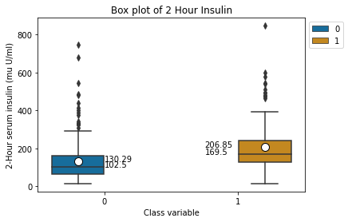

```python
sns.boxplot(y='2-Hour serum insulin (mu U/ml)', x='Class variable',
                 data=df2,
                 palette="colorblind",
                 hue='Class variable',showmeans=True,
           meanprops={"marker":"o",
                       "markerfacecolor":"white",
                       "markeredgecolor":"black",
                      "markersize":"10"})
plt.legend(bbox_to_anchor=(1, 1), loc=2)
plt.text(0,smean.loc[0],str((smean.loc[0])))
plt.text(1*.75,smean.loc[1],str((smean.loc[1])))
plt.text(0,smedian.loc[0],str((smedian.loc[0])))
plt.text(1*.75,smedian.loc[1],str((smedian.loc[1])))
plt.title("Box plot of 2 Hour Insulin")
```

**Observation for insulin level data :**

Outliers are observed, hence its preferred to use Median value for replacement of zeros. There is also significant difference in medians of diabetic and non-diabetic hence team decided to replace insulin level zero’s with

**Non-Diabetic --> 102.5**

**Diabetic --> 169.5**

```python
# find the grouped mean and median of skin fold thickness

smean = round(grouped_df['Triceps skin fold thickness (mm)'].mean(),2)
smedian =round(grouped_df['Triceps skin fold thickness (mm)'].median(),2)
```

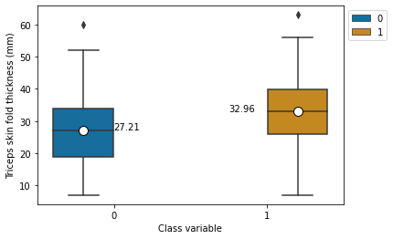

```python
sns.boxplot(y='Triceps skin fold thickness (mm)', x='Class variable',
                 data=df2,
                 palette="colorblind",
                 hue='Class variable',showmeans=True,
           meanprops={"marker":"o",
                       "markerfacecolor":"white",
                       "markeredgecolor":"black",
                      "markersize":"10"})
plt.legend(bbox_to_anchor=(1, 1), loc=2)

plt.text(0,smean.loc[0],str((smean.loc[0])))
plt.text(1*.75,smean.loc[1],str((smean.loc[1])))
```

**Observation for skin thickness data :**

There is no significant difference between the mean and median , hence zero values to be replaced with the corresponding mean values of diabetic and non-diabetic

**Group**

**Mean**

**Median**

Non-Diabetic

27.21

```
27
```

Diabetic

```
32.96
```

```
33
```

```python
# copy Dataframe to clean container before mutating
df_clean =df1
```

#### Replace rows with zero's in high sample population with suitable Mean / Median

```python
# replace insulin level zero values
df_clean['2-Hour serum insulin (mu U/ml)'] = np.where(((df_clean['2-Hour serum insulin (mu U/ml)']==0)&(df_clean['Class variable']==0)), 102.5, df_clean['2-Hour serum insulin (mu U/ml)'])
df_clean['2-Hour serum insulin (mu U/ml)'] = np.where(((df_clean['2-Hour serum insulin (mu U/ml)']==0)&(df_clean['Class variable']==1)), 169.5, df_clean['2-Hour serum insulin (mu U/ml)'])
```

```python
# replace skin thickness zeros
df_clean['Triceps skin fold thickness (mm)'] = np.where(((df_clean['Triceps skin fold thickness (mm)']==0)&(df_clean['Class variable']==0)), 27.21, df_clean['Triceps skin fold thickness (mm)'])
df_clean['Triceps skin fold thickness (mm)'] = np.where(((df_clean['Triceps skin fold thickness (mm)']==0)&(df_clean['Class variable']==1)), 32.96, df_clean['Triceps skin fold thickness (mm)'])
```

#### Drop rows with zero's with low sample population

```python
# drop zero values in plasma glucose
df_clean =df_clean[df_clean['Plasma glucose concentration a 2 hours in an oral glucose tolerance test'] > 0]
## df1.info()
```

```python
# drop zero values in blood pressure
df_clean =df_clean[df_clean['Diastolic blood pressure (mm Hg)'] > 0]
##df1.info()
```

```python
# drop zero values in BMI
df_clean =df_clean[df_clean['Body mass index (weight in kg/(height in m)^2)'] > 0]
##df1.info()
```

#### Rename long column names with alias to improve graph readablity

```python
df_clean.rename(columns={'Number of times pregnant':'No_Times_Pregnant',
                    'Plasma glucose concentration a 2 hours in an oral glucose tolerance test':'Plasma_Glucose',
                   'Diastolic blood pressure (mm Hg)':'Blood_Pressure',
                   'Triceps skin fold thickness (mm)':'Tricep_Skin_Thickness',
                   '2-Hour serum insulin (mu U/ml)':'Serum_Insulin',
                   'Body mass index (weight in kg/(height in m)^2)':'BMI',
                   'Diabetes pedigree function':'Pedigree',
                   'Age (years)':'Age',
                   'Class variable':'Results'},inplace=True)
df_clean.head()
```

|  | No_Times_Pregnant | Plasma_Glucose | Blood_Pressure | Tricep_Skin_Thickness | Serum_Insulin | BMI | Pedigree | Age | Results |
| --- | --- | --- | --- | --- | --- | --- | --- | --- | --- |
| 0 | 6 | 148 | 72 | 35.00 | 169.5 | 33.6 | 0.627 | 50 | 1 |
| 1 | 1 | 85 | 66 | 29.00 | 102.5 | 26.6 | 0.351 | 31 | 0 |
| 2 | 8 | 183 | 64 | 32.96 | 169.5 | 23.3 | 0.672 | 32 | 1 |
| 3 | 1 | 89 | 66 | 23.00 | 94.0 | 28.1 | 0.167 | 21 | 0 |
| 4 | 0 | 137 | 40 | 35.00 | 168.0 | 43.1 | 2.288 | 33 | 1 |

#### Check to see if all zero's have been mutated

```python
#This is to find how many column wise zero(0) rows are there!
print(df_clean.isin([0]).sum())
```

```
No_Times_Pregnant         99
Plasma_Glucose             0
Blood_Pressure             0
Tricep_Skin_Thickness      0
Serum_Insulin              0
BMI                        0
Pedigree                   0
Age                        0
Results                  475
dtype: int64
```

```python
df_clean.info()
```

```
<class 'pandas.core.frame.DataFrame'>
Int64Index: 724 entries, 0 to 767
Data columns (total 9 columns):
 #   Column                 Non-Null Count  Dtype
---  ------                 --------------  -----
 0   No_Times_Pregnant      724 non-null    int64
 1   Plasma_Glucose         724 non-null    int64
 2   Blood_Pressure         724 non-null    int64
 3   Tricep_Skin_Thickness  724 non-null    float64
 4   Serum_Insulin          724 non-null    float64
 5   BMI                    724 non-null    float64
 6   Pedigree               724 non-null    float64
 7   Age                    724 non-null    int64
 8   Results                724 non-null    int64
dtypes: float64(4), int64(5)
memory usage: 56.6 KB
```

we have been able to clean the dataframe with only 6% (768 to 724 rows) data loss with this.

#### Data Frame Cleaning Completed

4. Data Exploration

#### Univariate Analysis

```
<function matplotlib.pyplot.show(close=None, block=None)>
```

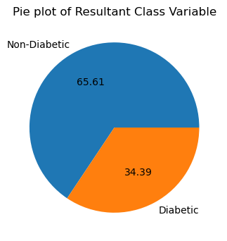

```python
vc =df_clean.Results.value_counts()
plt.figure(figsize =(5,4),dpi =100);plt.title ("Pie plot of Resultant Class Variable")
plt.pie(x=vc,autopct ='%.2f' ,labels=['Non-Diabetic','Diabetic']) ;plt.show
```

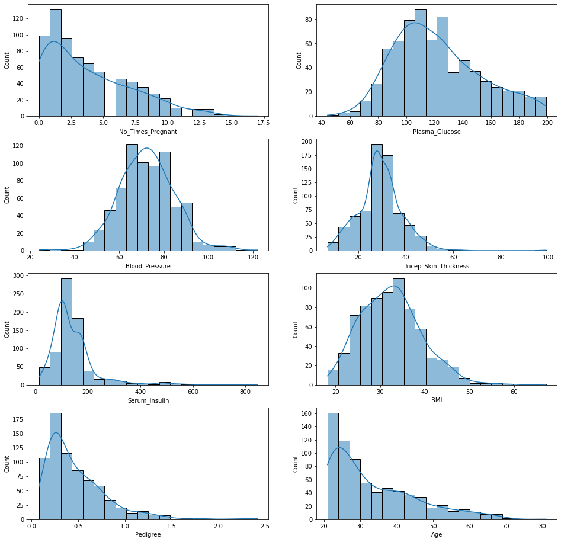

```python
fig, ax = plt.subplots(4,2, figsize=(16,16))
sns.histplot(df_clean.No_Times_Pregnant, bins = 20, ax=ax[0,0],kde=True)
sns.histplot(df_clean.Plasma_Glucose, bins = 20, ax=ax[0,1],kde=True)
sns.histplot(df_clean.Blood_Pressure, bins = 20, ax=ax[1,0],kde=True)
sns.histplot(df_clean.Tricep_Skin_Thickness, bins = 20, ax=ax[1,1],kde=True)
sns.histplot(df_clean.Serum_Insulin, bins = 20, ax=ax[2,0],kde=True)
sns.histplot(df_clean.BMI, bins = 20, ax=ax[2,1],kde=True)
sns.histplot(df_clean.Pedigree, bins = 20, ax=ax[3,0],kde=True)
sns.histplot(df_clean.Age, bins = 20, ax=ax[3,1],kde=True)
```

```python
df_clean.kurtosis()
```

```
No_Times_Pregnant         0.177770
Plasma_Glucose           -0.303662
Blood_Pressure            0.922883
Tricep_Skin_Thickness     4.635060
Serum_Insulin            13.145358
BMI                       0.936463
Pedigree                  5.626282
Age                       0.500877
Results                  -1.570710
dtype: float64
```

#### Pair plot to compare inter relation between variables

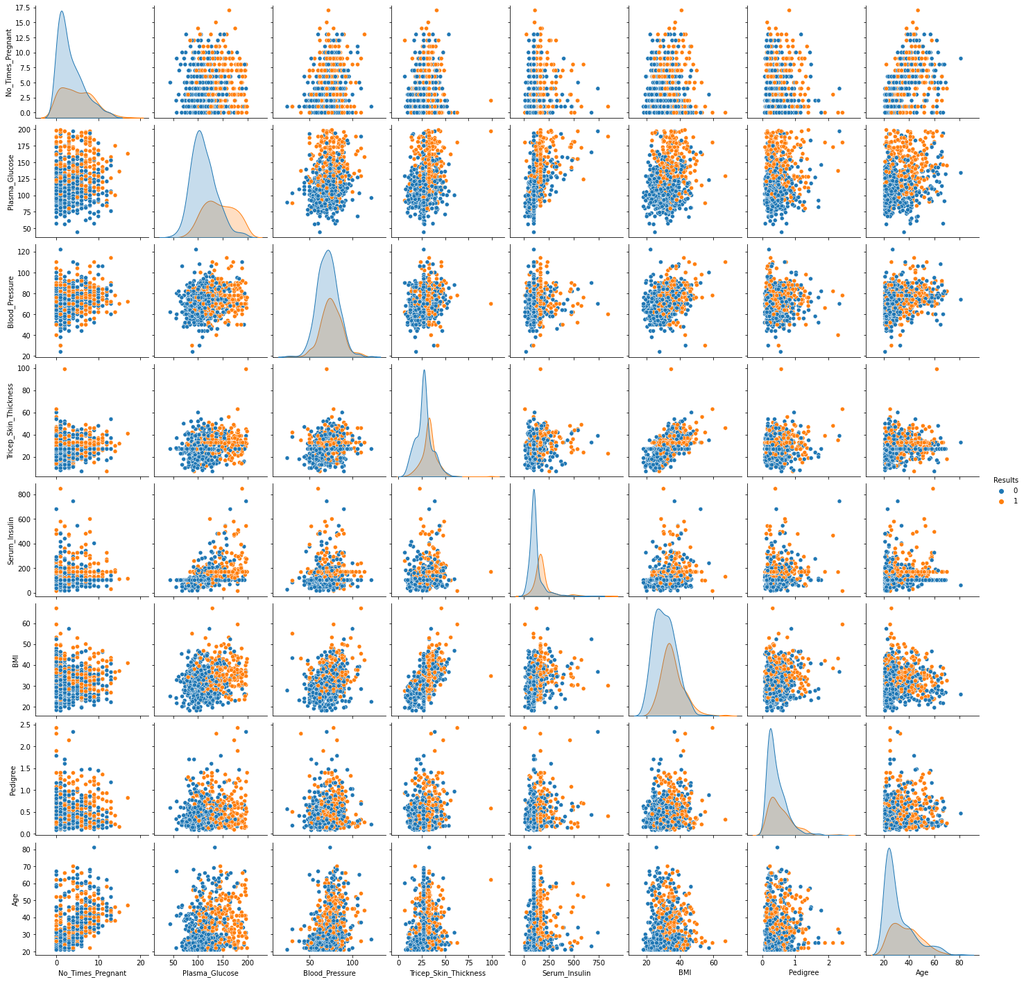

```python
sns.pairplot(df_clean, hue="Results", diag_kind = 'kde')
```

**Observation :** </b>  
there is large overlap in distribution between diabetic and non diabetic sub group  
Glucose with other variables shown some distint groupingv Further investatigation to be done with Pearson Correlation and plot heat maps

# Data Corelation

```python
df_clean.corr()
```

|  | No_Times_Pregnant | Plasma_Glucose | Blood_Pressure | Tricep_Skin_Thickness | Serum_Insulin | BMI | Pedigree | Age | Results |
| --- | --- | --- | --- | --- | --- | --- | --- | --- | --- |
| No_Times_Pregnant | 1.000000 | 0.134915 | 0.209668 | 0.091672 | 0.054297 | 0.012342 | -0.025996 | 0.557066 | 0.224417 |
| Plasma_Glucose | 0.134915 | 1.000000 | 0.223331 | 0.228634 | 0.488863 | 0.223276 | 0.136630 | 0.263560 | 0.488384 |
| Blood_Pressure | 0.209668 | 0.223331 | 1.000000 | 0.200021 | 0.065676 | 0.287403 | -0.000075 | 0.324897 | 0.166703 |
| Tricep_Skin_Thickness | 0.091672 | 0.228634 | 0.200021 | 1.000000 | 0.194423 | 0.571648 | 0.107155 | 0.134879 | 0.296808 |
| Serum_Insulin | 0.054297 | 0.488863 | 0.065676 | 0.194423 | 1.000000 | 0.232276 | 0.150360 | 0.122039 | 0.369064 |
| BMI | 0.012342 | 0.223276 | 0.287403 | 0.571648 | 0.232276 | 1.000000 | 0.154858 | 0.020835 | 0.299375 |
| Pedigree | -0.025996 | 0.136630 | -0.000075 | 0.107155 | 0.150360 | 0.154858 | 1.000000 | 0.023098 | 0.184947 |
| Age | 0.557066 | 0.263560 | 0.324897 | 0.134879 | 0.122039 | 0.020835 | 0.023098 | 1.000000 | 0.245741 |
| Results | 0.224417 | 0.488384 | 0.166703 | 0.296808 | 0.369064 | 0.299375 | 0.184947 | 0.245741 | 1.000000 |

# Heatmap

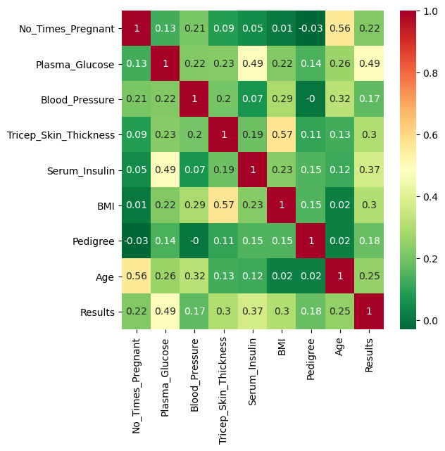

```python
cmatrix=round(df_clean.corr(),2)
plt.figure(figsize=(6,6),dpi=100)
sns.heatmap(cmatrix,annot=True,cmap='RdYlGn_r')
```

# Data Ranking against Result

```python
df2 = df_clean.corr()
df2['Rank'] =df2['Results'].rank(method='dense',axis=0,ascending=False);df2.sort_values(by ='Rank',ascending=True,inplace =True)
display(df2[['Results','Rank']])
```

|  | Results | Rank |
| --- | --- | --- |
| Results | 1.000000 | 1.0 |
| Plasma_Glucose | 0.488384 | 2.0 |
| Serum_Insulin | 0.369064 | 3.0 |
| BMI | 0.299375 | 4.0 |
| Tricep_Skin_Thickness | 0.296808 | 5.0 |
| Age | 0.245741 | 6.0 |
| No_Times_Pregnant | 0.224417 | 7.0 |
| Pedigree | 0.184947 | 8.0 |
| Blood_Pressure | 0.166703 | 9.0 |

**Observation :**  
we can see from ranking , glucose followed by other variables is most co related to results , however from heat map we also saw that glucose is equally co related to insulin , hence they react in tandem and only one of this variable is to be considered in building model to avoid inflation variance

5. Data Visualization & Analysis

### Density and Distribution plotting using Violin plot to get data-distribution of:

Serum Insulin

Plasma Glucose

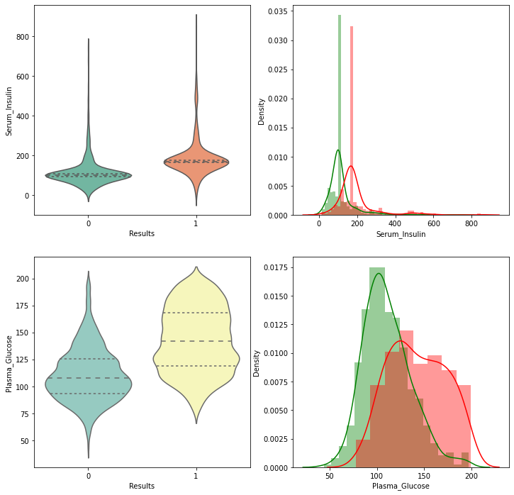

```python
fig,ax = plt.subplots(nrows=2, ncols=2, figsize=(12,12))

sns.violinplot(y="Serum_Insulin", x="Results", inner='quartile', ax=ax[0,0], palette='Set2', data=df_clean,
                dodge=False)
sns.distplot(df_clean[df_clean['Results'] == 0]["Serum_Insulin"], color='green',ax=ax[0,1]) # Healthy - green
sns.distplot(df_clean[df_clean['Results'] == 1]["Serum_Insulin"], color='red',ax=ax[0,1]) # Diabetic - Red

sns.violinplot(y="Plasma_Glucose", x="Results", inner='quartile', ax=ax[1,0],
                    data=df_clean, scale="width", palette='Set3', scale_hue=False, bw=.2)
sns.distplot(df_clean[df_clean['Results'] == 0]["Plasma_Glucose"], color='green',ax=ax[1,1]) # Healthy - green
sns.distplot(df_clean[df_clean['Results'] == 1]["Plasma_Glucose"], color='red',ax=ax[1,1]) # Diabetic - Red
```

### Result:

**Insulin:** Higher Insulin level indicates the presence of higher amount of blood sugar. For majority of Diabetic patients(violin plot - mean as well as density), 2 hr-Insulin level is higher(@170-180mu), while for Non-Diabetic patients it is around 100. The distplot shows that as insulin level increases, so does the count of the diabetic people

**Plasma Glucose Level:** Diabetes is caused when the blood sugar level is too high. There is a clear difference in the mean values of PGC level between Diabetic(142-145) and Non-Diabetic(108-110) sample. The distplot clearly depicts that healthier sample is at lower glucose levels, while with increase in glucose level, the no. of diabetic patients increase

### Density and Distribution plotting using Violin plot to get data-distribution of:

BMI

Triceps Skin Thickness

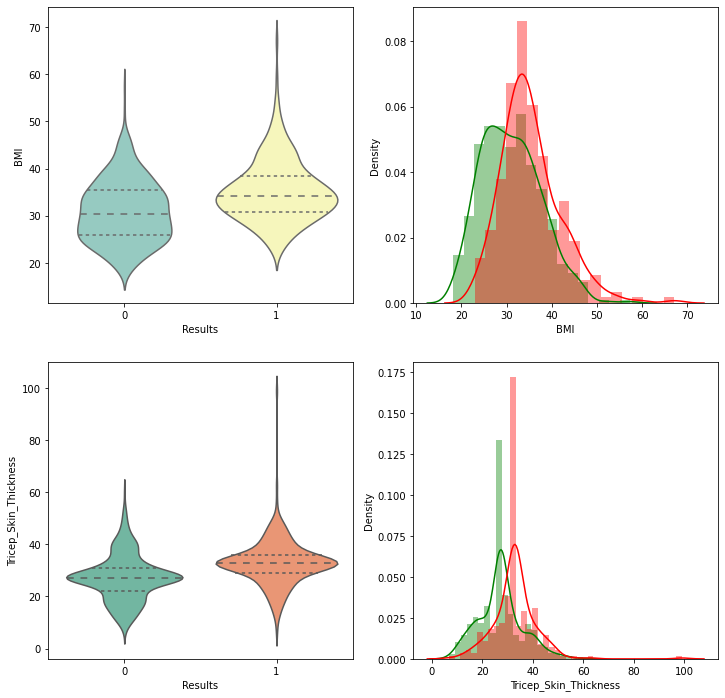

```python
fig,ax = plt.subplots(nrows=2, ncols=2, figsize=(12,12))

sns.violinplot(y="BMI",x="Results", palette='Set3', ax=ax[0,0], inner="quartile", data=df_clean)
sns.distplot(df_clean[df_clean['Results'] == 0]["BMI"], color='green',ax=ax[0,1]) # Healthy - green
sns.distplot(df_clean[df_clean['Results'] == 1]["BMI"], color='red',ax=ax[0,1]) # Diabetic - Red

sns.violinplot(y="Tricep_Skin_Thickness",x="Results", inner="quart", ax=ax[1,0], palette='Set2', data=df_clean)
sns.distplot(df_clean[df_clean['Results'] == 0]["Tricep_Skin_Thickness"], color='green',ax=ax[1,1]) # Healthy - green
sns.distplot(df_clean[df_clean['Results'] == 1]["Tricep_Skin_Thickness"], color='red',ax=ax[1,1]) # Diabetic - Red
```

### Result:

**BMI:** Below 18.5 Underweight 18.5 – 24.9 Normal or Healthy Weight 25.0 – 29.9 Overweight 30.0 and Above Obese . The more weight you have, the more your body becomes resistant to insulin. the mean of non-diabetic patients is 30, which is borderlining Obese, while the majority of the sample is around 25.0. While for the Diabetic sample, the mean as well as the majority is in the range of 34-37. We can infer that increase in BMI lead to higher chances of being diabetic

**Tricep Skin Thickness:** Diabetes causes a condition leading to increase in the thickness of the skin. The dist plot clearly shows that majority of diabetic patients are having thicker skin at triceps as compared to healthier sample.

### Density and Distribution plotting using Violin plot to get data-distribution of:

Age

Pregnancy Count

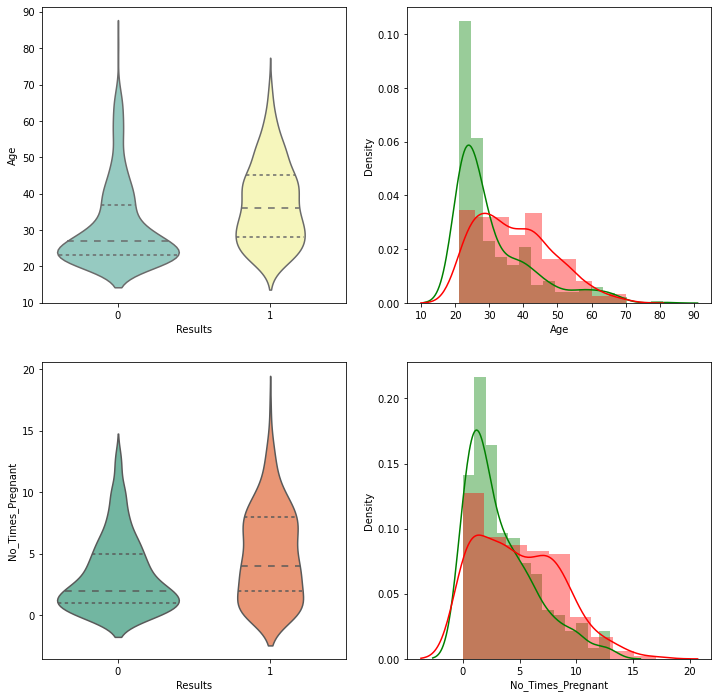

```python
fig,ax = plt.subplots(nrows=2, ncols=2, figsize=(12,12))

sns.violinplot(y="Age",x="Results", palette='Set3', ax=ax[0,0], inner="quartile", data=df_clean)
sns.distplot(df_clean[df_clean['Results'] == 0]["Age"], color='green',ax=ax[0,1]) # Healthy - green
sns.distplot(df_clean[df_clean['Results'] == 1]["Age"], color='red',ax=ax[0,1]) # Diabetic - Red

sns.violinplot(y="No_Times_Pregnant",x="Results", inner="quart", ax=ax[1,0], palette='Set2', data=df_clean)
sns.distplot(df_clean[df_clean['Results'] == 0]["No_Times_Pregnant"], color='green',ax=ax[1,1]) # Healthy - green
sns.distplot(df_clean[df_clean['Results'] == 1]["No_Times_Pregnant"], color='red',ax=ax[1,1]) # Diabetic - Red
```

### Result:

**Age:** The data clearly shows that at lower age of 20-25(First quartile to mean) most of the population is healthy and without diabetes. The distribution graph gives a clear indication, that with increase in age, the majority of the population is diabetic

**No of Times Pregnant:** The violin plot for pregnancies as well as the dist plot shows it clearly that the highest density of the both diabetic and non-diabetic sample can lie in the same range. This leaves this information as non-deterministic wrt chances of being diabetic

### Density and Distribution plotting using Violin plot to get data-distribution of:

Pedigree

Blood Pressure

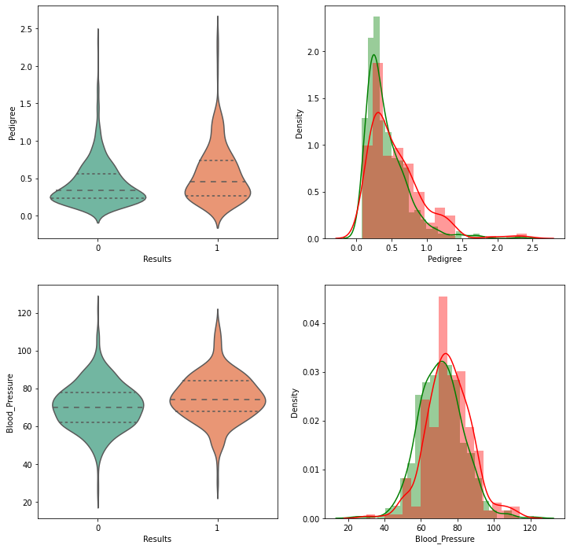

```python
fig,ax = plt.subplots(nrows=2, ncols=2, figsize=(12,12))

sns.violinplot(y="Pedigree",x="Results", palette='Set2', ax=ax[0,0], inner='quart', data=df_clean)
sns.distplot(df_clean[df_clean['Results'] == 0]["Pedigree"], color='green',ax=ax[0,1]) # Healthy - green
sns.distplot(df_clean[df_clean['Results'] == 1]["Pedigree"], color='red',ax=ax[0,1]) # Diabetic - Red

sns.violinplot(y="Blood_Pressure",x="Results", palette='Set2', ax=ax[1,0], inner='quart', data=df_clean)
sns.distplot(df_clean[df_clean['Results'] == 0]["Blood_Pressure"], color='green',ax=ax[1,1]) # Healthy - green
sns.distplot(df_clean[df_clean['Results'] == 1]["Blood_Pressure"], color='red',ax=ax[1,1]) # Diabetic - Red
```

### Result:

**Diabetic Pedigree:** This is basically the analysis of family genealogy to determine if it can be used to determine that someone is diabetic or not. Although the number having diabetes increase with the increae in the value of the pedigree, still the data at the max density is overlapping in both the plots. This is not a very clear indicator of determining if somebody is diabetic or not.

**Blood Pressure:** This is usually a very clear indicator, as diabetic patients have caused damage to their blood vessels due to increase in blood glucose level. But in the given dataset, the count of non-diabetic individuals with normal blood pressure of 80 is much high(388), as compared to the count of diabetic individuals with blood pressure above 100(9). This has caused the data to not clearly emphasize the impact of blood pressure on Diabetes

```python
print(len(df_clean.loc[(df_clean['Results'] == 1) & (df_clean['Blood_Pressure'] >= 100)]))
print(len(df_clean.loc[(df_clean['Results'] == 0) & (df_clean['Blood_Pressure'] <= 80)]))
```

```
9
388
```

6. Conclusion

From the above analysis, we can conclude the following:  
**Deterministic Attributes**

Plasma Glucose Level are the most clear indicators of detecting if a patient is Diabetic or not.

AGE

Tricep Skin Thickness

**Non Deterministic Attributes**

Pregnancy

Diabetic Pedigree

Blood Pressure

Also, our analysis are consistent with the correlation rank that we created for every column wrt Class variable.

Thank you for your attention,  
We are happy to answer any Questions you may have.